Project Work — Data Engineering & AI

# Intelligent Order Intake

Pipeline automatizzata su Microsoft Fabric. Dal PDF al dato strutturato e analitico, senza intervento manuale.

Microsoft Foundry Microsoft Fabric Medallion + Star Schema

A

Acme Manufacturing S.r.l.

↓USA LE FRECCE PER NAVIGARE

[figure not shown]

Dal caos dei documenti sparsi a una pipeline ordinata e automatica

01 — ARCHITETTURA

## Architettura Fabric end-to-end

Dal documento PDF alla tabella analitica consolidata, con un solo lancio di pipeline. Cinque stadi in sequenza, ognuno con una responsabilità precisa.

1

### PDF in arrivo

- Ordini, quotazioni, richieste info
- → pdf_inbox/ (OneLake)

2

### Agente AI (Foundry)

- Estrae JSON strutturato
- Classifica il tipo (ordine / quotazione / info)

3

### Notebook PySpark

- Validazione vs catalogo
- Matching cliente/articolo
- Coda di revisione aggregata per ordine

4

### Lakehouse (Medallion)

- Bronze → Silver → Gold
- Tabelle Delta su OneLake
- Star Schema analitico

5

### Dataflow Gen2

- Unione storico + PDF (Power Query M)
- Filtro qualità → fact_ordini consolidata
- Alimenta il modello DirectLake

⚡ Esecuzione manuale on-demand all'arrivo di nuovi documenti — con elaborazione incrementale: ogni run processa solo i PDF di pdf_inbox/ non ancora presenti in Bronze, senza mai ripartire da zero. Cinque attività in sequenza: 4 notebook + refresh del Dataflow.

02 — AGENTE AI

## Solo estrazione, non decisione

Microsoft Foundry, agente "PDF-Analyzer" — un compito unico e ben definito, non un tool-calling autonomo verso il gestionale.

COSA FA L'AGENTE

Legge il PDF e restituisce un JSON strutturato: dati cliente, riferimenti ordine, righe articolo. La classificazione del tipo documento (ordine / quotazione / richiesta info / non determinabile) è già inclusa nell'output — a valle serve solo validare, non interpretare.

singolo turno nessun tool call output: solo JSON

ordine_acme_042.pdf → estrazione

{

"tipo_documento": "ordine",

"cliente_ragione_sociale": "Rossi & Figli",

"cliente_partita_iva": "01234567890",

"riferimento_ordine": "ORD-2025-042",

"data_ordine": "18/06/2025",

"righe": [

{ "codice_articolo": "VT-0412", "quantita": 50 }

]

}

03 — VALIDAZIONE

## Perché no all'agente, sì a Python

L'agente estrae, il codice verifica. Ogni riga viene ricontrollata contro il Gestionale prima di contare come dato affidabile.

PERCHÉ IN PYTHON, NON NELL'AGENTE

L'agente lavora a singolo turno e senza tool-calling: legge il PDF e restituisce solo JSON. Ogni controllo contro l'anagrafica clienti/articoli avviene dopo, in PySpark, con chiamate REST dirette al backend del Gestionale — un solo punto di verità, più facile da tracciare e correggere di una logica nascosta nel prompt.

Match cliente

Partita IVA esatta, poi ragione sociale normalizzata (uguale o contenuta). Nessun match → id_cliente_match: null, intervento umano.

Match articolo

Codice esatto (confidenza alta) o descrizione per sovrapposizione di parole (confidenza alta/media/bassa). Nessuna corrispondenza → riga segnalata.

Coerenza quantità e prezzo

Quantità ≤ 0 o > 100.000, scostamento prezzo dichiarato/listino oltre l'1%, unità di misura diversa dal catalogo → tutte segnalate come anomalia.

Esito

intervento_umano_necessario più l'elenco dei motivi: il documento resta in Bronze/Silver, marcato per la Coda di Revisione, mai scartato.

04 — LAKEHOUSE

## Bronze & Silver

Ingestione grezza e pulizia tipizzata su Microsoft Fabric Lakehouse. Ogni livello del Medallion raffina il dato di un grado.

BBRONZE

Raw — così come arriva. Schema flessibile: nessuna predefinizione per tipo documento.

bronze_documenti_estratti

tabella unica di ingestione

pdf_nome

nome del file sorgente

tipo_documento

ordine / quotazione / richiesta_informazioni / non_determinabile

intervento_umano_necessario

flag boolean

data_elaborazione

timestamp del processing

json_completo

JSON grezzo dell'intero risultato

cleanse & parse

SSILVER

Cleaned — scomposto e tipizzato per tipo documento. Date multi-formato gestite via UDF Python (dd/MM/yyyy + yyyy-MM-dd).

da PDF

silver_ordini  
silver_ordini_righe

da PDF

silver_quotazioni  
silver_quotazioni_righe

da PDF

silver_richieste_info

da PDF

silver_documenti_non_gestiti

da Gestionale

silver_clienti_assets

da Gestionale

silver_articoli_assets

da Gestionale

silver_ordini_storici  
silver_ordini_righe_storiche

05 — GOLD

## Gold — Star Schema

Modello dimensionale analitico su Microsoft Fabric Lakehouse. Tre dimensioni convergono su un'unica tabella dei fatti.

dim_cliente

id_cliente  
ragione_sociale  
partita_iva  
citta · provincia

dim_articolo

codice_articolo  
descrizione  
categoria  
prezzo_listino ★

fact_ordini

id_ordine  
id_cliente (FK)  
id_data (FK)  
codice_articolo (FK)  
quantita  
prezzo_listino  
valore_riga

dim_data

id_data (yyyyMMdd)  
anno · mese · trimestre  
giorno_settimana  
settimana_anno

★ valore_riga = quantità × prezzo_listino — calcolato sempre da dim_articolo (Gestionale), mai preso dal documento originale. Il prezzo_dichiarato resta nel layer raw (fact_ordini_pdf) come colonna informativa per analizzare gli scostamenti dal listino.

✓ fact_ordini è consolidata da un Dataflow Gen2 a valle dei notebook: unisce fact_ordini_storici e fact_ordini_pdf ed esclude ogni riga con richiede_revisione = true — che resta tracciata nella coda di revisione (sezione successiva). Le quotazioni vivono in fact_quotazioni_pdf: non sono ordini confermati e non entrano nel fatturato.

06 — QUALITÀ DATI

## Coda di Revisione

Non tutto ciò che un agente AI estrae può entrare automaticamente nei numeri di fatturato. Ciò che non supera la validazione viene isolato, non scartato.

PERCHÉ A LIVELLO ORDINE

Un operatore riapre documenti, non singole righe. Se anche una sola riga di un ordine è anomala, l'intero documento richiede revisione — aggregare evita di presentare la stessa segnalazione ripetuta riga per riga.

[figure not shown]

aggregate by id_ordine

coda_revisione_ordini

Una riga per ordine, con tutto il contesto per decidere senza riaprire il PDF.

cliente_ragione_sociale_estratta

nome così come letto dal documento, anche se non risolto in anagrafica

id_cliente_risolto

null → cliente nuovo da censire o dato errato

righe_con_anomalia / numero_righe_totali

quanto è esteso il problema nel documento

dettaglio_anomalie

note concatenate e deduplicate

valore_stimato_totale

per prioritizzare — un ordine da 5.000€ prima di uno da 50€

motivo_principale

categoria sintetica per filtrare la coda

07 — POWER BI

## Report Power BI

Fatturato totale, numero ordini, andamento temporale, top clienti e articoli — modello semantico DirectLake su OneLake.

[interactive chart not shown]

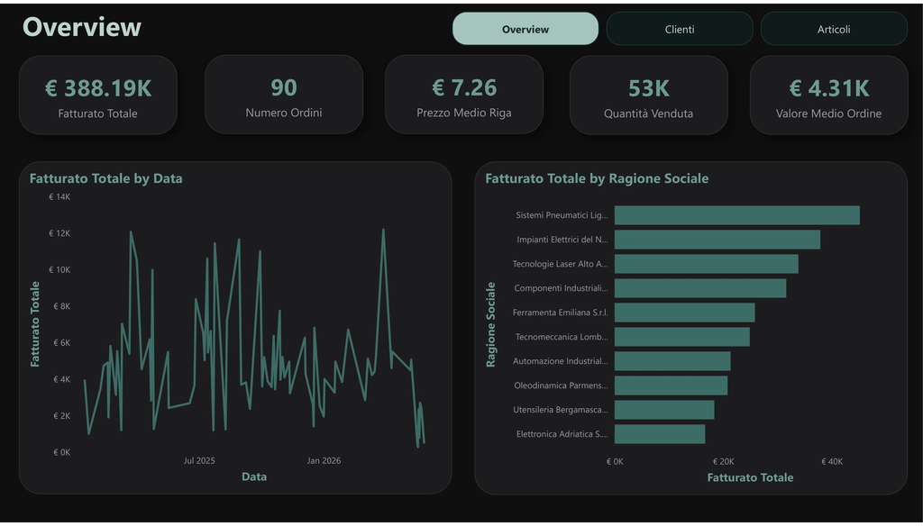

Overview

08 — LIMITI

## Limiti della soluzione

Un prototipo funzionante, non un sistema in produzione. Ogni scelta qui sotto è un compromesso consapevole, con l'alternativa architetturale che richiederebbe.

Un agente generico, non specializzato

Un solo agente PDF-Analyzer gestisce ordine, quotazione e richiesta info con lo stesso prompt. → Alternativa: più agenti specializzati per tipo documento, orchestrati da un router.

Validazione centralizzata in Python

Nessun tool-calling REST diretto verso il Gestionale: ogni scrittura passa da un unico script Python come collo di bottiglia. → Alternativa: più agenti con accesso diretto al Gestionale, orchestrati tra loro.

Autenticazione a token statico

TokenStaticoCredential richiede rinnovo manuale ogni ~1h. → Alternativa: Managed Identity, non attivabile per i limiti IAM del tenant condiviso.

Nessuna gestione errori/retry robusta

Retry, alerting e monitoraggio in produzione restano fuori scope, coerentemente con l'ambito di prototipo universitario. → Alternativa: circuit breaker, dead-letter queue e osservabilità end-to-end.

09 — RISULTATO

## Cosa è stato costruito

#### Ordine

Validazione cliente e articoli vs catalogo, verifica prezzo e unità di misura, flag intervento umano.

#### Quotazione

Bozza di offerta con prezzi calcolati automaticamente dal listino ufficiale del Gestionale → fact_quotazioni_pdf in Gold, separata dal fatturato.

#### Richiesta info

Ricerca articoli nel catalogo e generazione bozza di risposta da inoltrare all'operatore.

#### Non determinabile

Documenti ambigui o non leggibili → flag intervento_umano_necessario = true, archiviati in silver_documenti_non_gestiti per revisione manuale.

4

Notebook PySpark

01 estrai · 02 Bronze→Silver · 02b storico Gestionale · 03 Silver→Gold

B·S·G

Medallion su OneLake

Bronze · Silver · Gold in tabelle Delta

3+1

Star Schema

3 dim · fact_ordini consolidata via Dataflow Gen2 (storico + PDF, solo righe validate)

On-demand

Esecuzione pipeline

Lancio manuale all'arrivo di nuovi PDF · incrementale: riprocessa solo i non elaborati

01 / 09